# Valentina Falanga 325 Midterm

#Setup

```
library(dplyr)
library(ggplot2)
```

```
voters<-read.csv("/Users/valentinafalanga/Desktop/DIDA 325 data & society/new-voter-registrations.csv")
```

#Introduction Voter registration patterns give us insight into trends within populations of the United States. Knowing how and when people are registering can give us an understanding of how we should allocate our resources, helping us to better serve the American people. The goal of this project is to better understand voter registration trends over time as well as between States. It is our hope that the results help others, such as campaigns promoting voter registration to the general public, understand where their efforts are most needed.

#Data Introduction and Cleaning

```
voters %>%
  head(5)
```

|  | Jurisdiction | Year | Month | New.registered.voters |
| --- | --- | --- | --- | --- |
| 1 | Arizona | 2016 | Jan | 25852 |
| 2 | Arizona | 2016 | Feb | 51155 |
| 3 | Arizona | 2016 | Mar | 48614 |
| 4 | Arizona | 2016 | Apr | 30668 |
| 5 | Arizona | 2020 | Jan | 33229 |

```
#Jurisdiction: Name of the State
#Year: Year the data is from
#Month: Month the data is from
#New.Registered.voters: Number of newly registered voters in that state that month
```

#Checking for missing data

```
sum(is.na(voters))
```

```
[1] 0
```

```
#no missing data
```

#checking data types

```
str(voters)
```

```
'data.frame':   106 obs. of  4 variables:
 $ Jurisdiction         : chr  "Arizona" "Arizona" "Arizona" "Arizona" ...
 $ Year                 : int  2016 2016 2016 2016 2020 2020 2020 2020 2016 2016 ...
 $ Month                : chr  "Jan" "Feb" "Mar" "Apr" ...
 $ New.registered.voters: int  25852 51155 48614 30668 33229 50853 31872 10249 87574 103377 ...
```

```
#Data types chr, int, chr, int
```

#renaming columns

```
voters_2 <-voters %>%
  rename(NAME=Jurisdiction, registered_voters= New.registered.voters)
```

#Data Limitations

Some limitations of this data include that it is only from 2016 and 2020, skipping the non presidential election year of 2018 as well as only pull from a select few states, making it hard to generalize on a National scale. The timeframe being limited may limit our ability to see ongoing trends over that be more visible with a full year’s data.

#Most voters

```
voters_2 %>%
  select (NAME,Month,Year,registered_voters) %>%
  filter(registered_voters==max(registered_voters))
```

| NAME | Month | Year | registered_voters |
| --- | --- | --- | --- |
| California | Feb | 2020 | 238281 |

```
#The highest amount of new voter registration was February, 2020 in California with 238281 new registered voters
```

#Average voters

```
voters_2 %>%
  summarize(Average_voters=mean(registered_voters))
```

| Average_voters |
| --- |
| 48223.46 |

```
#The overall average is 48223.46 new voters per month
```

#Only above average data

```
high_voters <- voters_2 %>%
  filter(registered_voters >= 48223)

high_voters %>%
  count()
```

| n |
| --- |
| 36 |

```
#new voter registration was higher than the overall average 36 months total
```

#Amount of times states went above average

```
high_voters %>%
  group_by (NAME) %>%
  count(NAME) %>%
  arrange (desc(n))
```

| NAME | n |
| --- | --- |
| Texas | 8 |
| California | 7 |
| Florida | 7 |
| North Carolina | 6 |
| Illinois | 4 |
| Arizona | 3 |
| Georgia | 1 |

```
#Texas went above the average 8 times, California and Florida 7,North Carolina 6, Illinois 4, Arizona 3 and Georgia 1.
```

#Top 3 states with highest voter registration averages

```
voters_2 %>%
  group_by (NAME) %>%
  summarize (mean = mean(registered_voters)) %>%
  arrange (desc(mean)) %>%
  head(3)
```

| NAME | mean |
| --- | --- |
| California | 144545.38 |
| Texas | 114610.10 |
| Florida | 65868.12 |

```
#California, Texas and Florida had the highest overall average voter registration.
```

#Visualizing Registered Voters By State

```
voters_2 %>%
  group_by (NAME) %>%
  summarize(mean_in_thousands=mean(registered_voters/1000))
```

| NAME | mean_in_thousands |
| --- | --- |
| Arizona | 35.311500 |
| California | 144.545375 |
| Colorado | 20.527500 |
| Delaware | 3.166375 |
| District of Columbia | 3.248400 |
| Florida | 65.868125 |
| Georgia | 36.604125 |
| Illinois | 56.840375 |
| Maryland | 22.133500 |
| North Carolina | 56.040800 |

[output cut: 2 more lines]

```
ggplot(voters_2,aes(x=NAME,y=(registered_voters/1000),fill=registered_voters))+
  geom_bar(stat="Identity",position="dodge")+
  labs(x="State",y="Registered Voters (In Thousands)",title="Registered Voters By State")+
  theme(axis.text.x = element_text(angle = 45, hjust = 1, vjust = 1),legend.position="none")
```

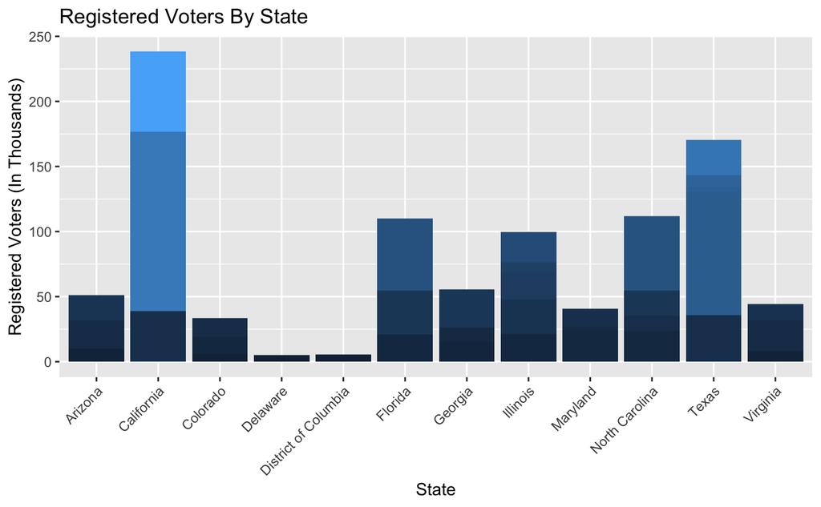

[output not shown]

#Visualizing Voter Registration in 2016 vs 2020

```
ggplot(voters_2,aes(x=Year,y=(registered_voters/1000), fill = Month))+
  geom_bar(stat="Identity")+
  scale_fill_manual(name="Month",values=c("black","darkblue", "blue", "lightblue","white"))+
  labs(x="Year",y="Registered Voters (in thousands)",title="Voter Registration in 2016 vs 2020")+
  theme(axis.text.x = element_text(angle = 0, hjust = 0, vjust = 0),legend.position="none")
```

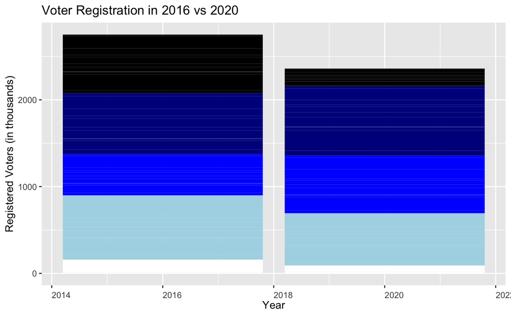

```
# There was clearly more overall voters registered in 2016 compared to 2020. Specifically, one month saw a dramatic decrease in voter registration from 2016 to 2020.
```

#Visualizing Voter Registration by Month

```
ggplot(voters_2,aes(x=Month,y=(registered_voters/1000), fill = Month))+
  geom_bar(stat="Identity")+
  scale_fill_manual(name="Month",values=c("black","darkblue", "blue", "lightblue","white"))+
  labs(x="Month",y="Registered Voters (in thousands)",title="Voter Registration by Month")+
  theme(axis.text.x = element_text(angle = 0, hjust = 0, vjust = 0))
```

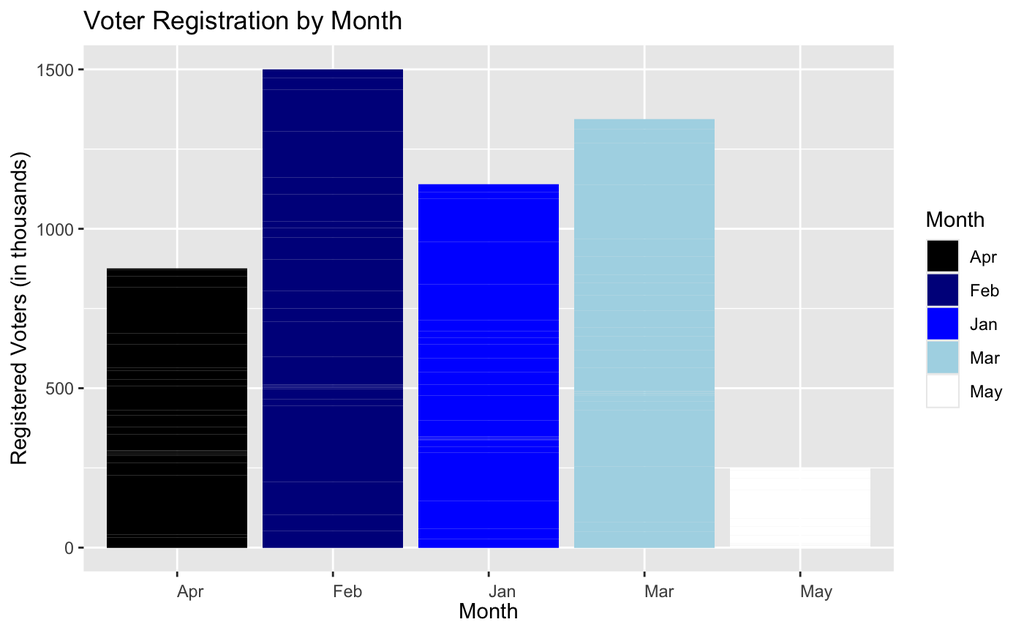

#Conclusion

From the analysis here, there is much that can be inferred about voter registration patterns across America. Despite the relatively restricted data, we can answer valuable questions. For example, while we asked what months of the year voter registration performed best overall, our analysis showed us very clearly that February performed the best, followed by March, January and April. May, on the other hand, performed abysmally compared to its counterparts, giving us valuable insight in voting registration trends. Those attempting to promote vote registration may want to focus their efforts on more popular months such as Jan-March and attempt to use the already existing momentum, or focus more on months such as May, when momentum has slowed. The Registered Voter by State visualization also gives these campaigns an idea of where to focus their efforts. States with higher populations such as Texas and California have big turnouts likely due to the sheer size of their population. Those wishing to promote voter registration should decide whether it would serve them best to focus on big or small states, whereas big states may result in bigger numbers, small states may be lacking personalized attention. Should we continue with this data, we would like to further explore state wide trends. Identifying states that have decreased in voter registration from 2016 to 2020 could be extremely valuable. In addition, expanding the data set would be ideal. More states, months and election years would help us better see trends when visualized. Finally, state population would extremely helpful in order to compare percent of population registering, rather than raw counts of people. This would better adjust for small vs big states in our analysis.

#Stakeholder Analysis

Our most prominent ethical concern in this situation is privacy and confidentiality breaches. While users may be consenting, their friends are not, meaning thousands of non-consenting people’s data are being sold and used against them through our product.

Most apparently, this situation is not abiding by the professional standard of upholding privacy and confidentiality. These severe breaches in non-users’ data is a serious issue and one we as a team must address immediately. Additionally, this raises concerns about whether we are contributing positively to society and working to reduce discrimination. The data sold is being used to in advertisements encouraging “unfavorable” populations not to vote, impeding on their constitutional right to vote. This raises serious question as to whether this product is negatively impacting the general population. Additionally, as isolated populationsare being targeted, one could argue we are actively supporting discrimination against these groups.

Despite this, I understand that we would like to continue working alongside this firm, as they are a loyal and profitable client. In order to serve the most people possible, while minimizing harm as much as possible, I propose instead of cutting off the firm, we impose new confidentiality regulations. We must ensure only data from conseting individuals can be collected. Any and all attempts at collecting data from friends of users but be harshly penalized and quickly removed. In this way, we can continue collaboration while minimizing harm to unwilling participants.

#Academic Integrity Statement By writing my name in the cell below, I certify that:

1. I did not use resources other than:
   - the Python notebooks provided by the instructor,
   - links provided in this notebook,
   - the assigned readings, and
   - my own personal notes
2. This means that I did not:
   - look up anything on Google, or Stack Overflow, Chatgpt, &c.,
   - discuss the content of the exam with *anyone* other than the instructors or TAs, or
   - do anything that technically doen’t break these rules but is against their spirit.

```
#Valentina Falanga
```